# Data 624 Project 2

Zach Herold, Anthony Pagan, Betsy Rosalen

5/10/2020

# Project Description

The data science team at ABC Beverage has been asked to provide an analysis of our manufacturing process, the predictive factors, and a predictive model of PH in order to comply with new regulations. This report details the steps taken in our analysis, including the assumptions made, the methodology used, the models tested, the model selected and the selection process, and the findings and conclusions reached from our analysis.

# Data Description

We were given a dataset that consisted of 31 numerical predictor variables detailing a wide range of production processes, 1 categorical variable `Brand.Code`, and our target variable, `PH`. Summary statistics for these variables can be seen in the two tables below.

Summary statistics for numerical variables

|  | n | mean | sd | min | median | max | range | skew | kurtosis | se |
| --- | --- | --- | --- | --- | --- | --- | --- | --- | --- | --- |
| PH | 2567 | 8.55 | 0.17 | 7.88 | 8.54 | 9.36 | 1.48 | -0.29 | 0.06 | 0.00 |
| Carb.Volume | 2561 | 5.37 | 0.11 | 5.04 | 5.35 | 5.70 | 0.66 | 0.39 | -0.47 | 0.00 |
| Fill.Ounces | 2533 | 23.97 | 0.09 | 23.63 | 23.97 | 24.32 | 0.69 | -0.02 | 0.86 | 0.00 |
| PC.Volume | 2532 | 0.28 | 0.06 | 0.08 | 0.27 | 0.48 | 0.40 | 0.34 | 0.67 | 0.00 |
| Carb.Pressure | 2544 | 68.19 | 3.54 | 57.00 | 68.20 | 79.40 | 22.40 | 0.18 | -0.01 | 0.07 |
| Carb.Temp | 2545 | 141.09 | 4.04 | 128.60 | 140.80 | 154.00 | 25.40 | 0.25 | 0.24 | 0.08 |
| PSC | 2538 | 0.08 | 0.05 | 0.00 | 0.08 | 0.27 | 0.27 | 0.85 | 0.65 | 0.00 |
| PSC.Fill | 2548 | 0.20 | 0.12 | 0.00 | 0.18 | 0.62 | 0.62 | 0.93 | 0.77 | 0.00 |
| PSC.CO2 | 2532 | 0.06 | 0.04 | 0.00 | 0.04 | 0.24 | 0.24 | 1.73 | 3.73 | 0.00 |
| Mnf.Flow | 2569 | 24.57 | 119.48 | -100.20 | 65.20 | 229.40 | 329.60 | 0.00 | -1.87 | 2.36 |
| Carb.Pressure1 | 2539 | 122.59 | 4.74 | 105.60 | 123.20 | 140.20 | 34.60 | 0.05 | 0.14 | 0.09 |
| Fill.Pressure | 2549 | 47.92 | 3.18 | 34.60 | 46.40 | 60.40 | 25.80 | 0.55 | 1.41 | 0.06 |
| Hyd.Pressure1 | 2560 | 12.44 | 12.43 | -0.80 | 11.40 | 58.00 | 58.80 | 0.78 | -0.14 | 0.25 |
| Hyd.Pressure2 | 2556 | 20.96 | 16.39 | 0.00 | 28.60 | 59.40 | 59.40 | -0.30 | -1.56 | 0.32 |
| Hyd.Pressure3 | 2556 | 20.46 | 15.98 | -1.20 | 27.60 | 50.00 | 51.20 | -0.32 | -1.57 | 0.32 |
| Hyd.Pressure4 | 2541 | 96.29 | 13.12 | 52.00 | 96.00 | 142.00 | 90.00 | 0.55 | 0.63 | 0.26 |
| Filler.Level | 2551 | 109.25 | 15.70 | 55.80 | 118.40 | 161.20 | 105.40 | -0.85 | 0.05 | 0.31 |
| Filler.Speed | 2514 | 3687.20 | 770.82 | 998.00 | 3982.00 | 4030.00 | 3032.00 | -2.87 | 6.71 | 15.37 |
| Temperature | 2557 | 65.97 | 1.38 | 63.60 | 65.60 | 76.20 | 12.60 | 2.39 | 10.16 | 0.03 |
| Usage.cont | 2566 | 20.99 | 2.98 | 12.08 | 21.79 | 25.90 | 13.82 | -0.54 | -1.02 | 0.06 |
| Carb.Flow | 2569 | 2468.35 | 1073.70 | 26.00 | 3028.00 | 5104.00 | 5078.00 | -0.99 | -0.58 | 21.18 |
| Density | 2570 | 1.17 | 0.38 | 0.24 | 0.98 | 1.92 | 1.68 | 0.53 | -1.20 | 0.01 |
| MFR | 2359 | 704.05 | 73.90 | 31.40 | 724.00 | 868.60 | 837.20 | -5.09 | 30.46 | 1.52 |
| Balling | 2570 | 2.20 | 0.93 | -0.17 | 1.65 | 4.01 | 4.18 | 0.59 | -1.39 | 0.02 |
| Pressure.Vacuum | 2571 | -5.22 | 0.57 | -6.60 | -5.40 | -3.60 | 3.00 | 0.53 | -0.03 | 0.01 |
| Oxygen.Filler | 2559 | 0.05 | 0.05 | 0.00 | 0.03 | 0.40 | 0.40 | 2.66 | 11.09 | 0.00 |
| Bowl.Setpoint | 2569 | 109.33 | 15.30 | 70.00 | 120.00 | 140.00 | 70.00 | -0.97 | -0.06 | 0.30 |
| Pressure.Setpoint | 2559 | 47.62 | 2.04 | 44.00 | 46.00 | 52.00 | 8.00 | 0.20 | -1.60 | 0.04 |
| Air.Pressurer | 2571 | 142.83 | 1.21 | 140.80 | 142.60 | 148.20 | 7.40 | 2.25 | 4.73 | 0.02 |
| Alch.Rel | 2562 | 6.90 | 0.51 | 5.28 | 6.56 | 8.62 | 3.34 | 0.88 | -0.85 | 0.01 |
| Carb.Rel | 2561 | 5.44 | 0.13 | 4.96 | 5.40 | 6.06 | 1.10 | 0.50 | -0.29 | 0.00 |
| Balling.Lvl | 2570 | 2.05 | 0.87 | 0.00 | 1.48 | 3.66 | 3.66 | 0.59 | -1.49 | 0.02 |

Summary of categorical variable, Brand.Code

|  | Brand.Code |
| --- | --- |
|  | : 120 |
|  | A: 293 |
|  | B:1239 |
|  | C: 304 |
|  | D: 615 |

## Distributions

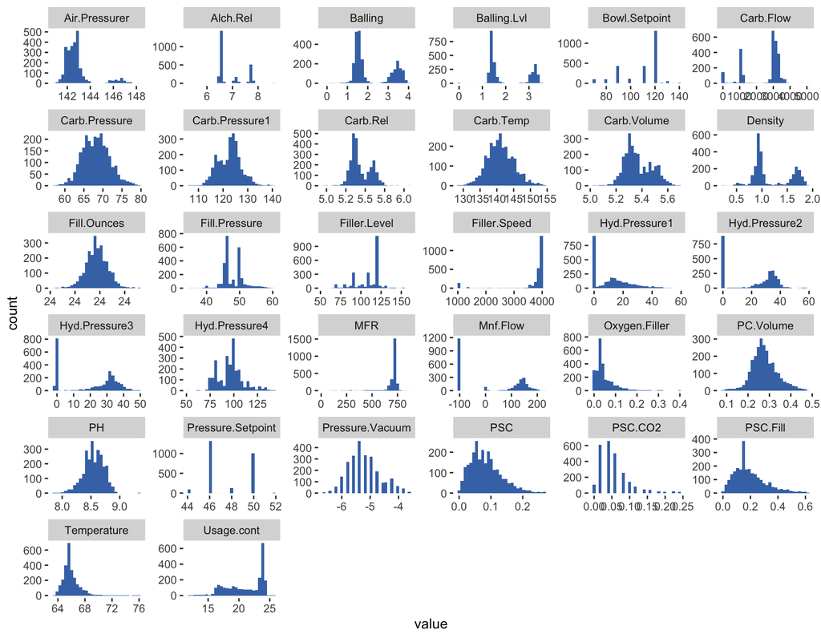

Since we only have one categorical variable, `Brand.Code`, which is related to brand and marketing rather than manufacturing process, we plotted it against each predictor and the target to see if there were any noticeable patterns that may be relevant to our model. As you can see in the plots below the brand code is evenly distributed among most predictors and most importantly evenly distributed in our target variable, `PH`, so it does not appear to have any predictive value and so was removed from our dataset for model training.

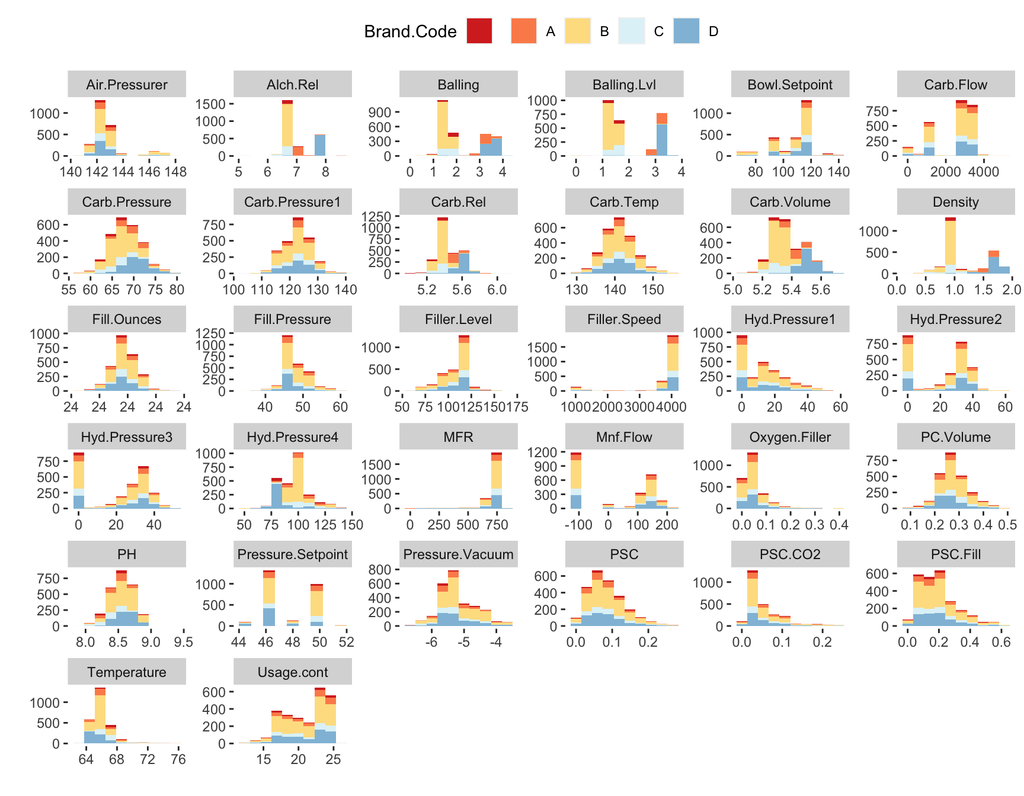

## Missing Values

There was some missing data in our predictors most noticeably in `MFR`, which had 8.25% missing values as can be seen in the plot below. There doesn’t seem to be any pattern in the missingness however, so it is unlikely that it has any predictive value.

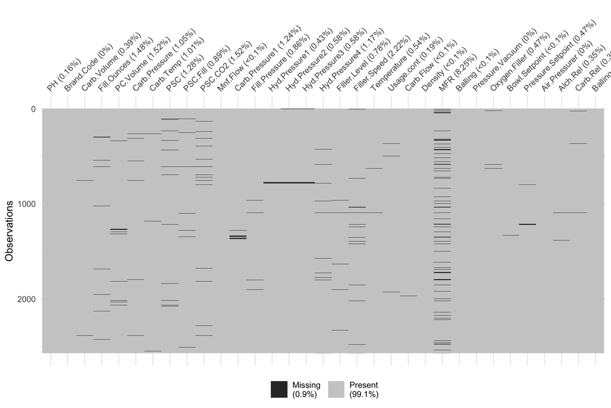

The plot below confirms that there is no apparent pattern in the missing values. Incomplete cases comprise only about 17% of the substantial dataset, and since there did not seem to be any patterns to the missingness, the decision was made to remove them completely from our dataset leaving us with the remaining 2129 complete cases.

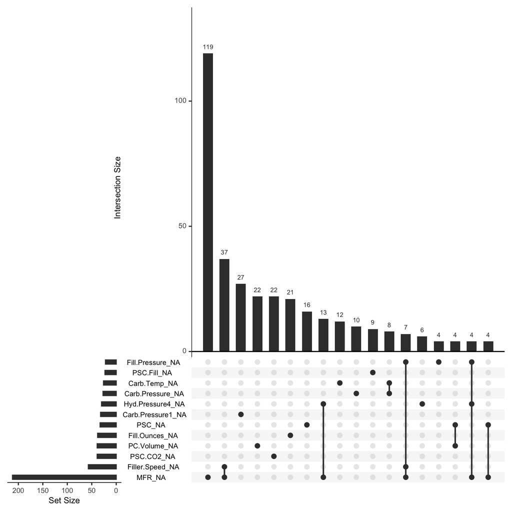

## Relationships Between Variables

The plots below were used to assess if there were any clear linear relationships between the predictors and the target, `PH`. Few, if any, relationships are immediately apparent.

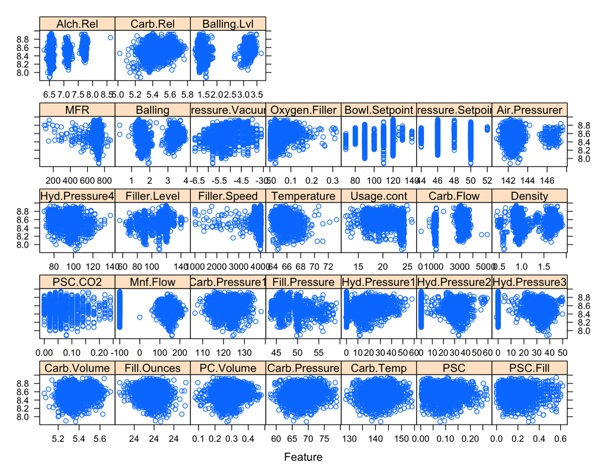

A correlation plot shows some strong correlations between predictors. The `findCorrelation` function from the `caret` library recommends removing the `MFR`, `Hyd.Pressure2`, `Carb.Rel`, `Air.Pressurer`, `Carb.Flow`, `Hyd.Pressure4`, and `Filler.Level` variables at a 0.85 correlation cutoff. Upping the cutoff to 0.9 only removes one variable, `Carb.Flow`, from that list.

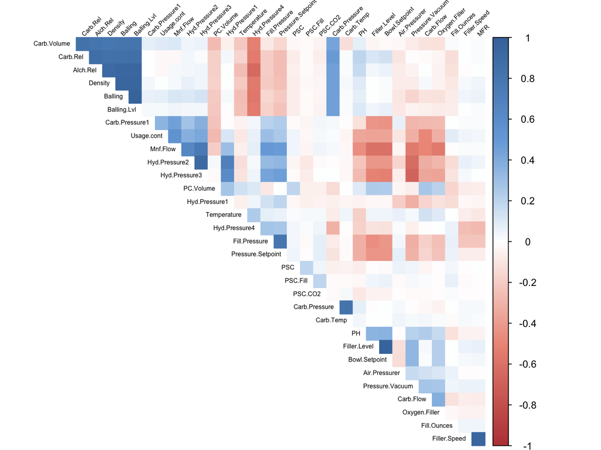

Variables recommended for removal by caret::findCorrelation function at the 0.85 cutoff

| x |
| --- |
| MFR |
| Hyd.Pressure2 |
| Carb.Rel |
| Air.Pressurer |
| Carb.Flow |
| Hyd.Pressure4 |
| Filler.Level |

# Models

We randomly partitioned our dataset into training and validation subsets with 70% for training and 30% set aside for testing.

```
##                                    RMSE            Rsquared                 MAE
##          "linPred:"  "0.14148799339231"  "0.37751558349577" "0.107282082278634"
```

```
##                                    RMSE            Rsquared                 MAE
##        "ridgePred:"  "0.14148369195348" "0.377576156883878" "0.107291529168727"
```

```
##                                    RMSE            Rsquared                 MAE
##        "lassoPred:" "0.141448727080631" "0.378208369727554" "0.107380376499913"
```

```
##                                    RMSE            Rsquared                 MAE
##          "forPred:" "0.116224112541366" "0.588967102285951" "0.084544328889208"
```

```
##                                      RMSE             Rsquared
##           "bagPred:"  "0.127700157227922"  "0.505259826677652"
##                  MAE
## "0.0967585360332601"
```

```
##                                    RMSE            Rsquared                 MAE
##         "ctrePred:" "0.151958166789516" "0.280400816493112" "0.117948127662675"
```

```
##                                    RMSE            Rsquared                 MAE
##         "cartPred:" "0.159321851250287" "0.205363937099158" "0.124543439674693"
```

```
##                                    RMSE            Rsquared                 MAE
##         "marsPred:" "0.139991943389293" "0.391285532715141" "0.103523358270636"
```

```
##                                    RMSE            Rsquared                 MAE
##          "knnPred:" "0.139736261136218" "0.386507495716948" "0.104601413192962"
```

```
##                                      RMSE             Rsquared
##           "svmPred:"  "0.131000389768039"  "0.490430728248433"
##                  MAE
## "0.0933972137065225"
```

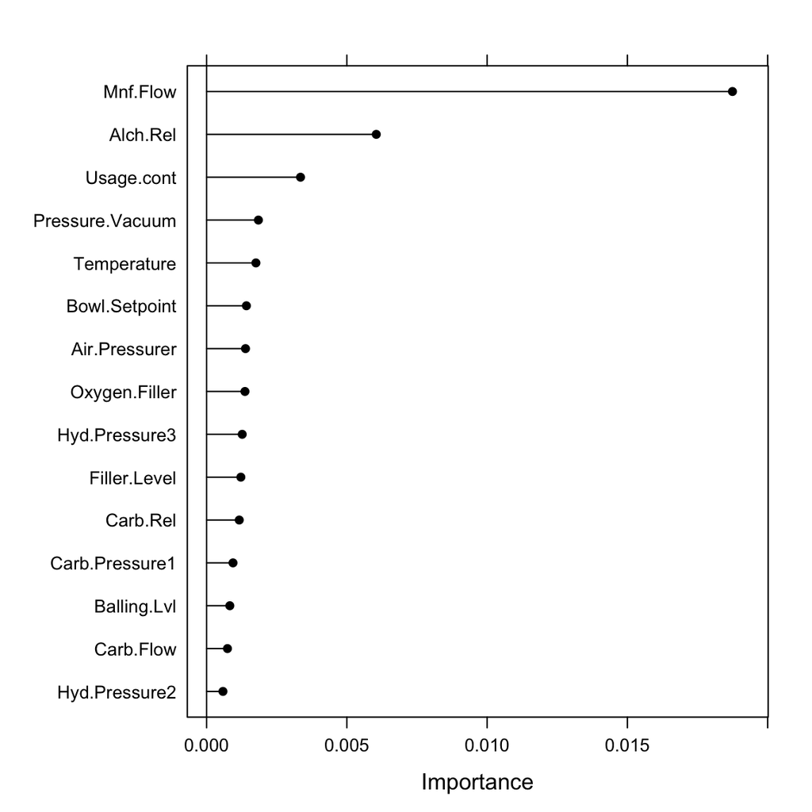

```
## cforest variable importance
##
##   only 20 most important variables shown (out of 31)
##
##                    Overall
## Mnf.Flow          0.018744
## Alch.Rel          0.006048
## Usage.cont        0.003348
## Pressure.Vacuum   0.001846
## Temperature       0.001757
## Bowl.Setpoint     0.001418
## Air.Pressurer     0.001386
## Oxygen.Filler     0.001367
## Hyd.Pressure3     0.001269
## Filler.Level      0.001221
## Carb.Rel          0.001163
## Carb.Pressure1    0.000940
## Balling.Lvl       0.000827
## Carb.Flow         0.000743
## Hyd.Pressure2     0.000582
## Hyd.Pressure1     0.000552
## Pressure.Setpoint 0.000421
## Density           0.000333
## Filler.Speed      0.000301
## PC.Volume         0.000257
```

### Top Five Most Important

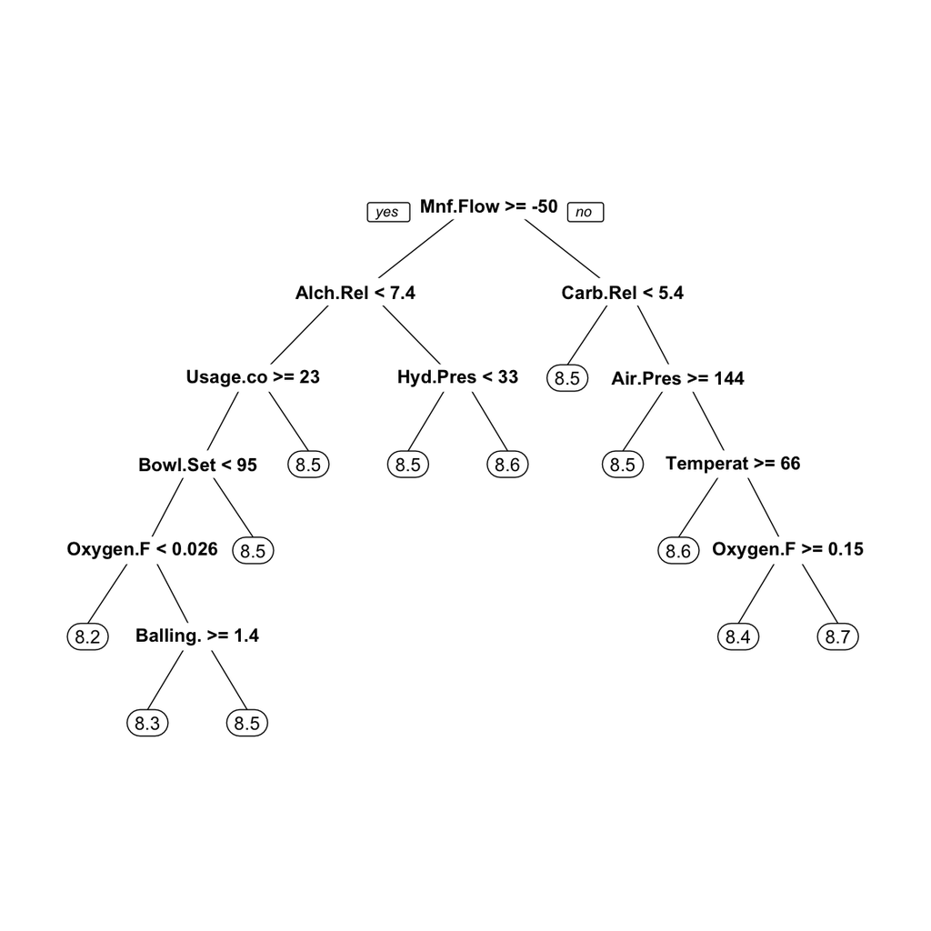

```
##     RMSE Rsquared      MAE
##    0.111    0.609    0.076
```

|  | %IncMSE | IncNodePurity |
| --- | --- | --- |
| Mnf.Flow | 0.01 | 6.73 |
| Usage.cont | 0.01 | 4.54 |
| Bowl.Setpoint | 0.01 | 2.76 |
| Temperature | 0.00 | 2.68 |
| Carb.Rel | 0.00 | 2.42 |
| Filler.Level | 0.00 | 2.32 |
| Balling.Lvl | 0.00 | 2.19 |
| Oxygen.Filler | 0.00 | 2.15 |
| Alch.Rel | 0.00 | 2.04 |
| Carb.Pressure1 | 0.00 | 1.84 |
| Pressure.Vacuum | 0.00 | 1.84 |
| Balling | 0.00 | 1.63 |
| Air.Pressurer | 0.00 | 1.42 |
| Carb.Flow | 0.00 | 1.37 |
| Density | 0.00 | 1.26 |
| Filler.Speed | 0.00 | 1.25 |
| Hyd.Pressure3 | 0.00 | 1.20 |
| MFR | 0.00 | 1.10 |
| PC.Volume | 0.00 | 1.06 |
| Carb.Volume | 0.00 | 1.05 |
| Fill.Pressure | 0.00 | 1.01 |
| Fill.Ounces | 0.00 | 0.95 |
| Hyd.Pressure2 | 0.00 | 0.91 |
| Hyd.Pressure4 | 0.00 | 0.86 |
| PSC | 0.00 | 0.80 |
| Pressure.Setpoint | 0.00 | 0.80 |
| Hyd.Pressure1 | 0.00 | 0.79 |
| Carb.Pressure | 0.00 | 0.76 |
| Carb.Temp | 0.00 | 0.74 |
| PSC.Fill | 0.00 | 0.65 |
| PSC.CO2 | 0.00 | 0.45 |

```
##
## Call:
## lm(formula = .outcome ~ ., data = dat)
##
## Residuals:
##     Min      1Q  Median      3Q     Max
## -0.5939 -0.0776  0.0104  0.0987  0.3996
##
## Coefficients:
##               Estimate Std. Error t value             Pr(>|t|)
## (Intercept) 10.0225971  0.2632923   38.07 < 0.0000000000000002 ***
## Mnf.Flow    -0.0005661  0.0000369  -15.34 < 0.0000000000000002 ***
## Usage.cont  -0.0062890  0.0015331   -4.10      0.0000431478915 ***
## Alch.Rel     0.0495725  0.0076656    6.47      0.0000000001354 ***
## Temperature -0.0252431  0.0036413   -6.93      0.0000000000061 ***
## ---
## Signif. codes:  0 '***' 0.001 '**' 0.01 '*' 0.05 '.' 0.1 ' ' 1
##
## Residual standard error: 0.14 on 1485 degrees of freedom
## Multiple R-squared:  0.28,   Adjusted R-squared:  0.279
## F-statistic:  145 on 4 and 1485 DF,  p-value: <0.0000000000000002
```

**note the negative coefficients of Mnf.Flow, Usage.conf, Temperature; positive of Alch.Rel**

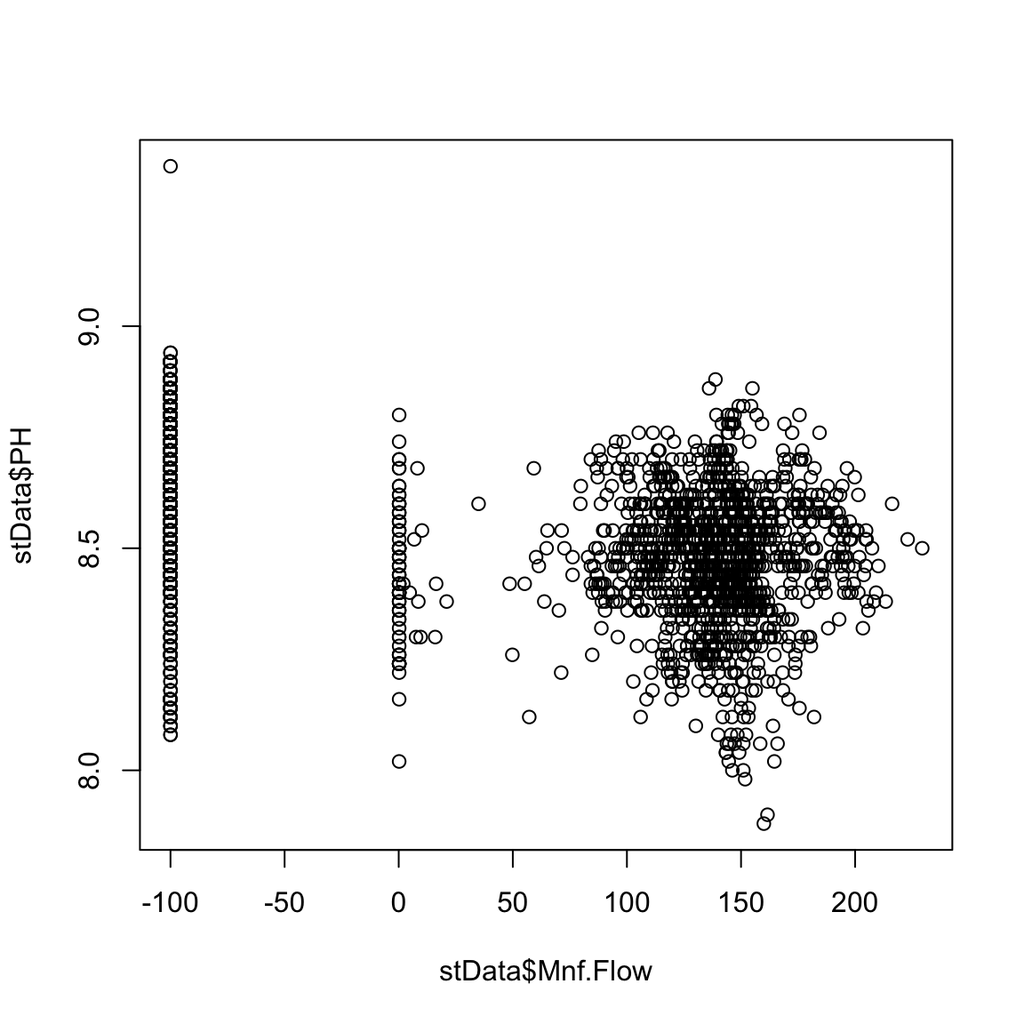

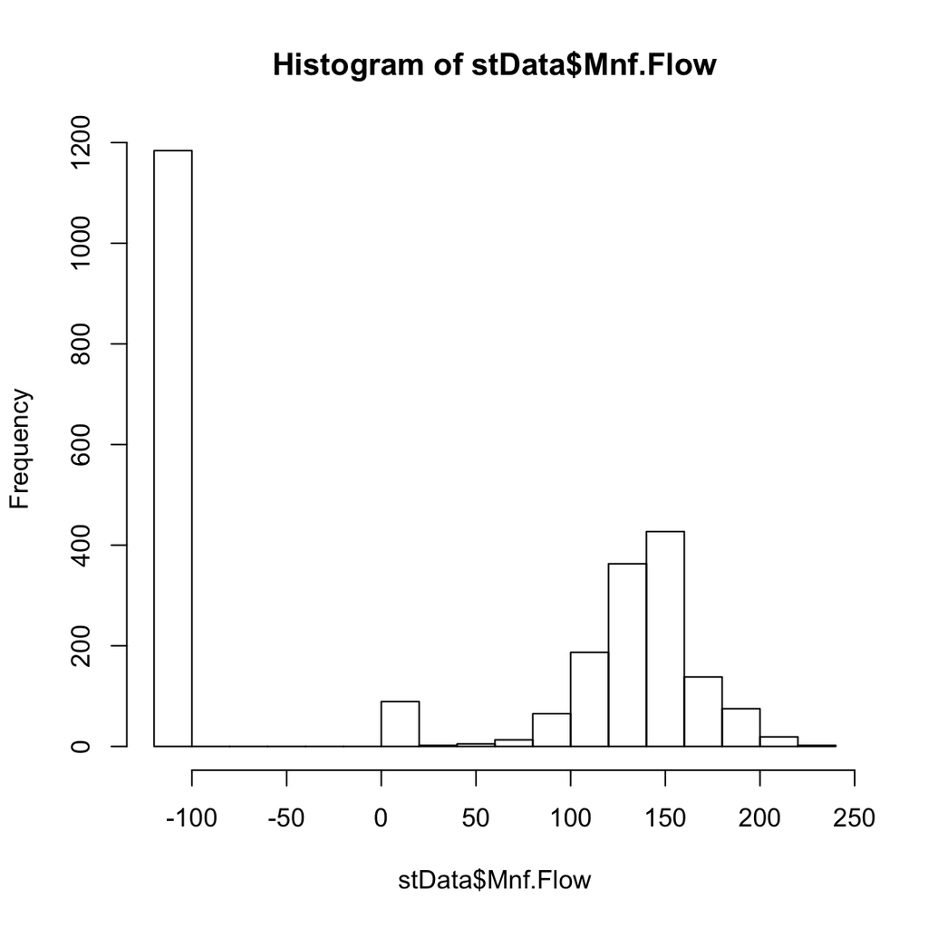

```
## [1] 2571
```

```
## [1] 442
```

```
## [1] 0.83
```

```
## [1] 0.012
```

```
## [1] 0.87
```

```
## [1] 0.032
```

```
##
##    1    2    3    4
## 1184   79  637  669
```

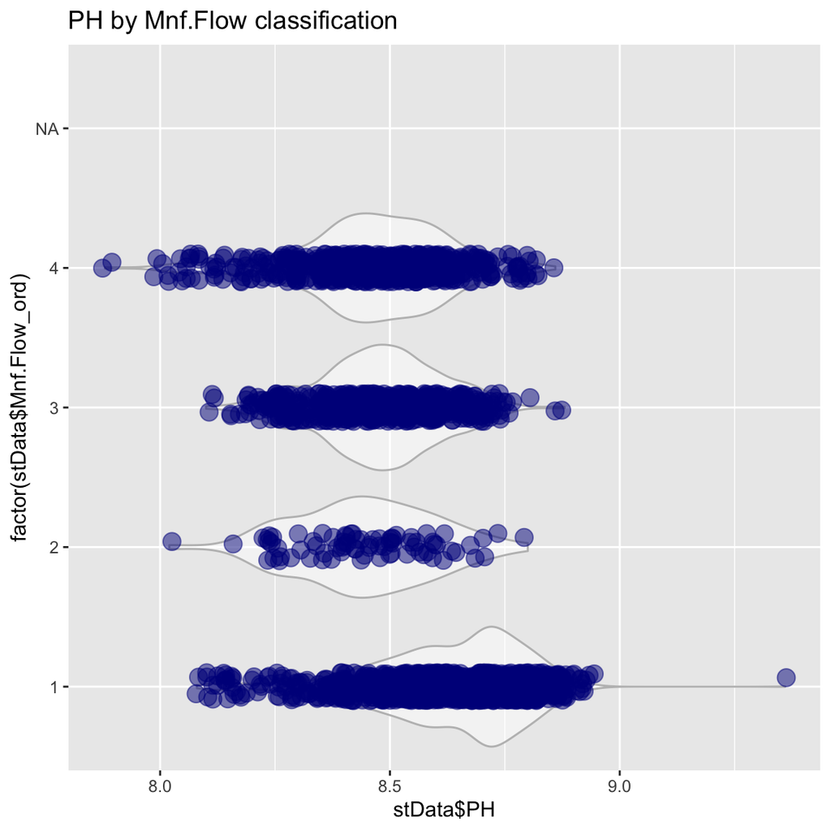

```
##     RMSE Rsquared      MAE
##     0.17     0.12     0.14
```

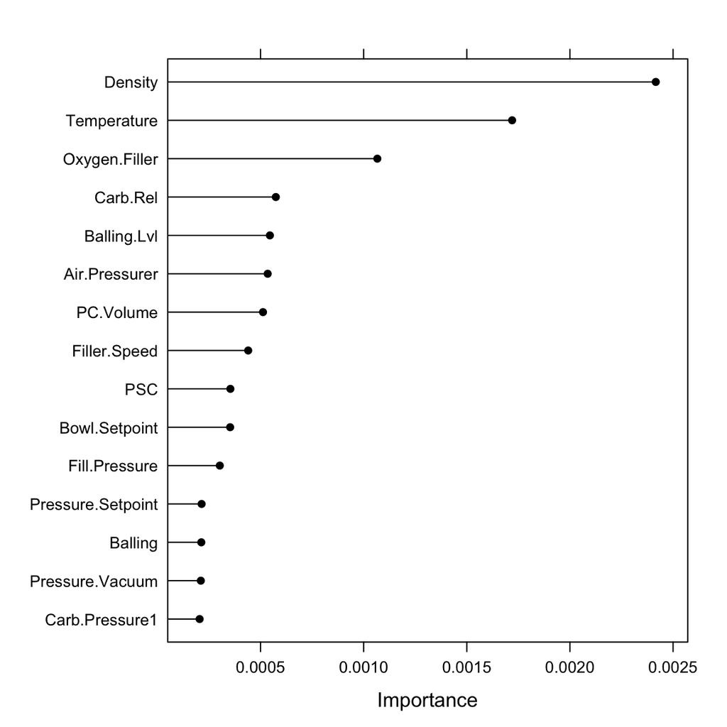

# Appendix

**Code used in analysis**

```r
knitr::opts_chunk$set(echo = FALSE, message = FALSE, warning = FALSE)
options(scipen=999, digits = 2)

library(AppliedPredictiveModeling)
library(caret)
library(dplyr)
library(e1071)
library(earth)
library(faraway)
library(fpp2)
library(ggplot2)
library(gridExtra)
library(kableExtra)
require(knitr)
library(leaps)
library(lubridate)
library(MASS)
library(mlbench)
library(naniar)
library(pander)
library(pROC)
library(psych)
library(readxl)
library(reshape)
library(reshape2)
library(tidyr)
library(tseries)
library(urca)
library(ZIM)

# Table formatting functions
kab_tab <- function(df, cap){
  df %>% kable(caption=cap) %>%
  kable_styling(bootstrap_options = c("striped", "hover", "condensed"),
                full_width = T)
}
kab_tab2 <- function(df, cap){
  df %>% kable(caption=cap) %>%
  kable_styling(bootstrap_options = c("striped", "hover", "condensed"),
                full_width = F)
}
# kab_tab_pdf <- function(df, cap){
#     kable(df, caption=cap, "latex", booktabs = T) %>%
#         kable_styling(latex_options = c("striped", "HOLD_position", "scale_down"))
# }
#Import Data
stEval<- read.csv("https://raw.githubusercontent.com/apag101/data624Group5/master/Project2/StudentEvaluation.csv?token=AB3M6K7RXH65YIAKWZBQ6KK6XA7R2", header = TRUE)
stData<- read.csv("https://raw.githubusercontent.com/apag101/data624Group5/master/Project2/StudentData.csv?token=AB3M6K4AYHCT5HBFJYHCCSC6XBACQ", header = TRUE)
# move PH to the first column of the dataframe
stData <- stData[,c(26,1:25,27:33)]
stEval <- stEval[,c(26,1:25,27:33)]
# https://stackoverflow.com/questions/5863097/selecting-only-numeric-columns-from-a-data-frame

num_sum <- describe(Filter(is.numeric, stData))
kab_tab(num_sum[,c(2,3,4,8,5,9,10:13)], cap="Summary statistics for numerical variables")

cat_sum <- summary(Filter(is.factor, stData))
kab_tab(cat_sum, cap="Summary of categorical variable, Brand.Code")
stData[,-2] %>%
  gather() %>%
  ggplot(aes(value)) +
    facet_wrap(~ key, scales = "free") +
    geom_histogram(fill = '#4575b4') +
  theme(panel.background = element_blank(), legend.position="top")
stData %>%
  gather(-Brand.Code, key = "var", value = "val") %>%
  ggplot(aes(x = val, fill=Brand.Code)) +
  geom_histogram(bins=10, alpha=1) +
  facet_wrap(~ var, scales = "free") +
  scale_fill_manual("Brand.Code",
                    values = c('#d73027','#fc8d59','#fee090',
                               '#e0f3f8','#91bfdb','#4575b4')) +
  xlab("") +
  ylab("") +
  theme(panel.background = element_blank(), legend.position="top")
stData <- stData[-2]
# Missing Data
vis_miss(stData)
gg_miss_upset(stData,
              nsets = 12,
              nintersects = 18)
summary(complete.cases(stData))
cstData <- subset(stData[-2], complete.cases(stData))
#plot checks
featurePlot(cstData[-1],cstData$PH)
#Correlation Matrix
library(corrplot)
cor.plt <- cor(cstData, use = "pairwise.complete.obs", method = "pearson")
col <- colorRampPalette(c("#BB4444", "#EE9988", "#FFFFFF", "#77AADD", "#4477AA"))
corrplot(cor.plt, method="color", col=col(200),
         type="upper", order="hclust",
         tl.col="black", tl.srt=45, tl.cex=0.5,
         diag=FALSE
         )
kab_tab(names(cstData)[findCorrelation(cor(cstData[-1]), cutoff = .85)],
        cap = "Variables recommended for removal by caret::findCorrelation function at the 0.85 cutoff")
#Partition Data
set.seed(123)
trainidx<-sample(nrow(cstData),round(0.7*nrow(cstData)),replace=F)
traindata<-cstData[trainidx,]
testdata<-cstData[-trainidx,]
require(caret)
trctrl<- trainControl(method="repeatedcv", number=3,repeats=2)

##Linear Regression
linreg <- caret::train(PH~., data=traindata, method="lm",
                trControl=trctrl)
linPred <- predict(linreg, newdata = testdata)
c('linPred:',postResample(pred = linPred, obs = testdata$PH)) #0.1414880 0.3775156

##Ridge Regression
ridge <- caret::train(PH~., data=traindata, method="ridge",
                trControl=trctrl)
ridgePred <- predict(ridge, newdata = testdata)
c('ridgePred:',postResample(pred = ridgePred, obs = testdata$PH)) #0.1414837 0.3775762

##Lasso Regression
lasso <- caret::train(PH~., data=traindata, method="lasso",
                trControl=trctrl)
lassoPred <- predict(lasso, newdata = testdata)
c('lassoPred:',postResample(pred = lassoPred, obs = testdata$PH)) #0.1418941 0.3762947

##RandomForest (Processed)
rforest <- caret::train(PH~., data=traindata, method="cforest",
                trControl=trctrl,
                tuneLength =2)
forPred <- predict(rforest, newdata = testdata)
c('forPred:',postResample(pred = forPred, obs = testdata$PH)) #0.11550844 0.59451507

##Tree Bag
bag <- caret::train(PH~., data=traindata, method="treebag",
                trControl=trctrl,
                tuneLength =2)
bagPred <- predict(bag, newdata = testdata)
c('bagPred:',postResample(pred = bagPred, obs = testdata$PH)) #0.12790436 0.50718903

##CTree
ctre <- caret::train(PH~., data=traindata, method="ctree2",
                trControl=trctrl,
                tuneLength =2)
ctrePred <- predict(ctre, newdata = testdata)
c('ctrePred:',postResample(pred = ctrePred, obs = testdata$PH)) #0.1519582 0.2804008

##CART
rcart<- caret::train(PH~., data=traindata, method="rpart",
                trControl=trctrl,
                tuneLength =2)
cartPred <- predict(rcart, newdata = testdata)
c('cartPred:',postResample(pred = cartPred, obs = testdata$PH)) #0.1593219 0.2053639

##MARS
marsFit <- earth(PH~., data = traindata, degree=2, nprune=14)
marsPred <- predict(marsFit, newdata = testdata)
c('marsPred:',postResample(pred = marsPred, obs = testdata$PH)) #0.1399919 0.3912855

##KNN
knnGrid <-  expand.grid(k = 1:20)
knnFit <- caret::train(PH~., data = traindata,
                method = "knn",
                trControl = trctrl,
                tuneGrid = knnGrid)
knnPred <- predict(knnFit, newdata = testdata)
c('knnPred:',postResample(pred = knnPred, obs = testdata$PH)) #0.1278504 0.5088682

##SVM (Radial Kernel)
svmGrid <-  expand.grid(C = c(1,1000))
svmFit <- caret::train(PH~., data = traindata,
                 #type='eps-regression',
                 method = 'svmRadialCost',
                 trControl = trctrl,
                 tuneGrid = svmGrid)
svmPred <- predict(svmFit, newdata = testdata)
c('svmPred:', postResample(pred = svmPred, obs = testdata$PH)) #0.13136218 0.48751241
#Variable Importance Ranking (Random Forest)
rfImp <- varImp(rforest, scale = FALSE)
bookTheme()
plot(rfImp, top=15, scales = list(y = list(cex = 0.8)))
rfImp
#install.packages('rpart.plot')
library(rpart.plot)
tree <- rpart(PH~., data=traindata)
prp(tree)
library(randomForest)
#Using full dataset (applying na.roughfix to missing values)
cstData_all<-subset(stData[-2])
set.seed(123)
trainidx2<-sample(nrow(cstData_all),round(0.7*nrow(cstData_all)),replace=F)
traindata2<-cstData_all[trainidx2,]
testdata2<-cstData_all[-trainidx2,]

##Additional Random Forest tuning (TUNE HERE)
#rf.model2 <- randomForest(PH~., data=traindata2, na.action=na.roughfix)
rf.model2 <- randomForest(PH~., data=traindata2, na.action=na.roughfix, importance=TRUE)
rfPred2 <- predict(rf.model2, newdata = testdata2)
postResample(pred = rfPred2, obs = testdata2$PH) #0.1097018 0.6173039
#with importance=TRUE, uses approach by Breiman to calculate the variable importance reported as MeanDecreaseAccuracy
#https://stackoverflow.com/questions/37888619/difference-between-varimp-caret-and-importance-randomforest-for-random-fores
rfImp2 <- as.data.frame(importance(rf.model2, scale = FALSE))
rfImp2[order(-rfImp2[,2]),]
##Linear Regression using only top 2 variables (Mnf.Flow & Usage.cont)
linreg2 <- caret::train(PH~Mnf.Flow+Usage.cont+Alch.Rel+Temperature, data=traindata, method="lm",
                trControl=trctrl)
summary(linreg2) # Adjusted R-squared:  0.2785
#Visualing the Mnf.Flow column
plot(stData$Mnf.Flow, stData$PH)
hist(stData$Mnf.Flow)
#Investigating percent of null values in ranged bins of Mnf.Flow
nrow(stData) #2571 rows
sum(!complete.cases(stData)) #442 rows with missing data

neg.Mnf.Flow.count <- nrow(stData[stData$Mnf.Flow < 0,]) #1186 rows with negative values
neg.complete.Mnf.Flow.count <- sum(complete.cases(stData[stData$Mnf.Flow < 0,])) #989 complete cases
neg.complete.Mnf.Flow.count / neg.Mnf.Flow.count #0.8338954

nearzeros.Mnf.Flow.count <- nrow(stData[stData$Mnf.Flow >= 0 & stData$Mnf.Flow <= 1 ,]) #81 rows
nearzeros.complete.Mnf.Flow.count <-sum(complete.cases(stData[stData$Mnf.Flow >= 0 & stData$Mnf.Flow <= 1 ,]))
nearzeros.complete.Mnf.Flow.count / nearzeros.Mnf.Flow.count #0.01234568 1% of data complete

pos.Mnf.Flow.count <- nrow(stData[stData$Mnf.Flow > 1,]) #1308 total rows with with Mnf.Flow greater than 50
pos.complete.Mnf.Flow.count <- sum(complete.cases(stData[stData$Mnf.Flow > 1,])) #1140 complete cases with Mnf.Flow greater than 50
pos.complete.Mnf.Flow.count / pos.Mnf.Flow.count #0.8707951 87% of data complete


nearzeros.Mnf.Flow.count / nrow(stData) #.03150 3% of the total number of rows accounts for 18% of the missing values

#Finding the mean of the Mnf.FLow from subset of values greater than 1, used in binning
#pos.Mnf.Flow <- stData[stData$Mnf.Flow > 1,]
#mean(pos.Mnf.Flow$Mnf.Flow, na.rm = T)
#Separating the Mnf.Flow column by thresholds
stData$Mnf.Flow_ord <- cut(
  stData$Mnf.Flow,
  breaks = c(-Inf, -1, 1, 140, Inf),
  labels = c(1, 2, 3, 4),
  right  = FALSE
)
table(stData$Mnf.Flow_ord)
#Violin plot of Mnf.Flow by bins
g <-ggplot(stData, aes(x=factor(stData$Mnf.Flow_ord), y=stData$PH))
g+geom_violin(alpha=0.5, color='grey') +
  geom_jitter(alpha=0.5, size=4, aes(), position = position_jitter(width = 0.1), color='darkblue', show.legend=FALSE) +
  ggtitle("PH by Mnf.Flow classification") +
  coord_flip()
#Subsetting data by brand
brandA <- stData[stData$Brand.Code == 'A',]
brandB <- stData[stData$Brand.Code == 'B',]
brandC <- stData[stData$Brand.Code == 'C',]
brandD <- stData[stData$Brand.Code == 'D',]

###Add Trimmed Means to NA Value
r <- colnames(cstData_all)[ apply(cstData_all, 2, anyNA)]

cstData_all[,colnames(cstData_all) %in% r]<-data.frame(sapply(cstData_all[,colnames(cstData_all) %in% r],
      function(x) ifelse(is.na(x),
            mean(x, na.rm = TRUE, trim = .1),
            x)))

#BrandA Training/Test Splitting
set.seed(123)
trainidxA<-sample(nrow(brandA),round(0.7*nrow(brandA)),replace=F)
traindataA<-cstData_all[trainidxA,]
testdataA<-cstData_all[-trainidxA,]


##RandomForest (on BrandA)
trctrl<- trainControl(method="repeatedcv", number=2,repeats=2)
rforestA <- caret::train(PH~., data=traindataA, method="cforest",
                trControl=trctrl, tuneLength =2, na.action=na.omit)
forPredA <- predict(rforestA, newdata = testdataA)
postResample(pred = forPredA, obs = testdataA$PH) #why NA?
#Variable Importance Ranking (on Brand A)
rfImpA <- varImp(rforestA, scale = FALSE)
plot(rfImpA, top=15, scales = list(y = list(cex = 0.8)))
```